# Weekly Exercises #6

Cheyenne Woerman

```r
library(tidyverse)     # for data cleaning and plotting
library(googlesheets4) # for reading googlesheet data
library(lubridate)     # for date manipulation
library(openintro)     # for the abbr2state() function
library(palmerpenguins)# for Palmer penguin data
library(maps)          # for map data
library(ggmap)         # for mapping points on maps
library(gplots)        # for col2hex() function
library(RColorBrewer)  # for color palettes
library(sf)            # for working with spatial data
library(leaflet)       # for highly customizable mapping
library(ggthemes)      # for more themes (including theme_map())
library(plotly)        # for the ggplotly() - basic interactivity
library(gganimate)     # for adding animation layers to ggplots
library(gifski)        # for creating the gif (don't need to load this library every time,but need it installed)
library(transformr)    # for "tweening" (gganimate)
library(shiny)         # for creating interactive apps
library(patchwork)     # for nicely combining ggplot2 graphs
library(gt)            # for creating nice tables
library(rvest)         # for scraping data
library(robotstxt)     # for checking if you can scrape data
gs4_deauth()           # To not have to authorize each time you knit.
library(rsconnect)
theme_set(theme_minimal())
```

```r
# Lisa's garden data
garden_harvest <- read_sheet("https://docs.google.com/spreadsheets/d/1DekSazCzKqPS2jnGhKue7tLxRU3GVL1oxi-4bEM5IWw/edit?usp=sharing") %>%
  mutate(date = ymd(date))
```

```
## Reading from "2020_harvest"
```

```
## Range "Sheet1"
```

```r
#COVID-19 data from the New York Times
covid19 <- read_csv("https://raw.githubusercontent.com/nytimes/covid-19-data/master/us-states.csv")
```

## Put your homework on GitHub!

Go [here](https://github.com/llendway/github_for_collaboration/blob/master/github_for_collaboration.md) or to previous homework to remind yourself how to get set up.

Once your repository is created, you should always open your **project** rather than just opening an .Rmd file. You can do that by either clicking on the .Rproj file in your repository folder on your computer. Or, by going to the upper right hand corner in R Studio and clicking the arrow next to where it says Project: (None). You should see your project come up in that list if you’ve used it recently. You could also go to File –> Open Project and navigate to your .Rproj file.

## Your first `shiny` app

1. This app will also use the COVID data. Make sure you load that data and all the libraries you need in the `app.R` file you create. Below, you will post a link to the app that you publish on shinyapps.io. You will create an app to compare states’ cumulative number of COVID cases over time. The x-axis will be number of days since 20+ cases and the y-axis will be cumulative cases on the log scale (`scale_y_log10()`). We use number of days since 20+ cases on the x-axis so we can make better comparisons of the curve trajectories. You will have an input box where the user can choose which states to compare (`selectInput()`) and have a submit button to click once the user has chosen all states they’re interested in comparing. The graph should display a different line for each state, with labels either on the graph or in a legend. Color can be used if needed.

```r
covid_weekly <- covid19 %>%
  group_by(state) %>%
  mutate(cases_weekly = lag(cases, n = 7, order_by = date),
         new_cases_weekly = (cases - cases_weekly),
         new_cases_weekly = replace_na(new_cases_weekly, 0)) %>%
  filter(new_cases_weekly >= 20)
```

```r
[Link](https://cwoerman.shinyapps.io/ShinyApp/?_ga=2.104064834.372942890.1602641142-1768631944.1602641142)
```

## Warm-up exercises from tutorial

2. Read in the fake garden harvest data. Find the data [here](https://github.com/llendway/scraping_etc/blob/main/2020_harvest.csv) and click on the `Raw` button to get a direct link to the data.

```r
garden_harvest_raw <- read.csv("https://raw.githubusercontent.com/llendway/scraping_etc/main/2020_harvest.csv")
```

5. Create a table using `gt` with data from your project or from the `garden_harvest` data if your project data aren’t ready.

```r
garden_harvest_gt <- garden_harvest %>%
  gt()
```

```r
garden_harvest_gt %>%
  tab_header(title = "Garden Harvest Data",
             subtitle = "RAW")
```

Garden Harvest Data

RAW

| vegetable | variety | date | weight | units |
| --- | --- | --- | --- | --- |
| lettuce | reseed | 2020-06-06 | 20 | grams |
| radish | Garden Party Mix | 2020-06-06 | 36 | grams |
| lettuce | reseed | 2020-06-08 | 15 | grams |
| lettuce | reseed | 2020-06-09 | 10 | grams |
| radish | Garden Party Mix | 2020-06-11 | 67 | grams |
| lettuce | Farmer's Market Blend | 2020-06-11 | 12 | grams |
| spinach | Catalina | 2020-06-11 | 9 | grams |
| beets | leaves | 2020-06-11 | 8 | grams |
| radish | Garden Party Mix | 2020-06-13 | 53 | grams |
| lettuce | Farmer's Market Blend | 2020-06-13 | 19 | grams |
| spinach | Catalina | 2020-06-13 | 14 | grams |
| kale | Heirloom Lacinto | 2020-06-13 | 10 | grams |
| lettuce | Farmer's Market Blend | 2020-06-17 | 48 | grams |
| spinach | Catalina | 2020-06-17 | 58 | grams |
| peas | Magnolia Blossom | 2020-06-17 | 8 | grams |
| peas | Super Sugar Snap | 2020-06-17 | 121 | grams |
| chives | perrenial | 2020-06-17 | 8 | grams |
| strawberries | perrenial | 2020-06-18 | 40 | grams |
| lettuce | Farmer's Market Blend | 2020-06-18 | 47 | grams |
| spinach | Catalina | 2020-06-18 | 59 | grams |
| beets | leaves | 2020-06-18 | 25 | grams |
| spinach | Catalina | 2020-06-19 | 58 | grams |
| lettuce | Farmer's Market Blend | 2020-06-19 | 39 | grams |
| beets | leaves | 2020-06-19 | 11 | grams |
| lettuce | Farmer's Market Blend | 2020-06-19 | 38 | grams |
| lettuce | Farmer's Market Blend | 2020-06-20 | 22 | grams |
| spinach | Catalina | 2020-06-20 | 25 | grams |
| lettuce | Tatsoi | 2020-06-20 | 18 | grams |
| radish | Garden Party Mix | 2020-06-20 | 16 | grams |
| peas | Magnolia Blossom | 2020-06-20 | 71 | grams |

[output cut: 655 more lines]

6. Use `patchwork` operators and functions to combine at least two graphs using your project data or `garden_harvest` data if your project data aren’t read.

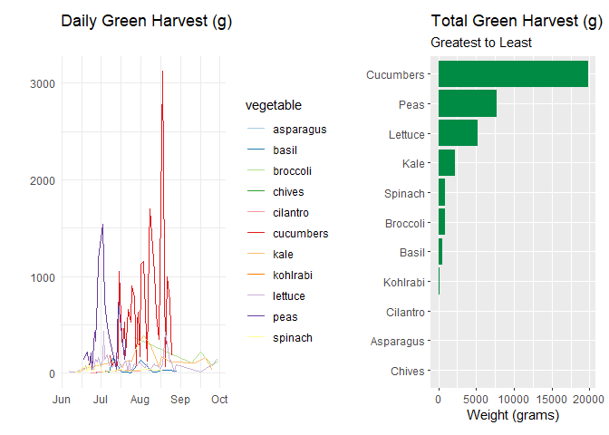

```r
g1 <- garden_harvest %>%
  filter(vegetable %in% c("zuccini", "cucumbers", "peas", "lettuce", "edemame", "swiss chard", "kale", "jalepeno", "spinach", "broccoli", "basil", "cilantro", "asparagus", "chives", "kohlrabi")) %>%
  group_by(vegetable) %>%
  summarize(sum_weight = sum(weight)) %>%
  arrange((desc(sum_weight))) %>%
  mutate(vegetable_cap = str_to_title(vegetable)) %>%
  ggplot(aes(x = sum_weight,
             y = fct_reorder(vegetable_cap, sum_weight)))+
  geom_col(fill = "springgreen4") +
  labs(title = "Total Green Harvest (g)",
       subtitle = "Greatest to Least",
       x = "Weight (grams)",
       y = "") +
  theme_grey()
g2 <- garden_harvest %>%
    filter(vegetable %in% c("zuccini", "cucumbers", "peas", "lettuce", "edemame", "swiss chard", "kale", "jalepeno", "spinach", "broccoli", "basil", "cilantro", "asparagus", "chives", "kohlrabi")) %>%
  group_by(vegetable, date) %>%
  summarise(daily_harvest_wt = sum(weight)) %>%
  ggplot(aes(x = date,
             y = daily_harvest_wt,
             color = vegetable)) +
  geom_line() +
  scale_color_brewer(palette = "Paired") +
  labs(title = "Daily Green Harvest (g)",
       x = "",
       y = "")
g2|g1
```

**DID YOU REMEMBER TO UNCOMMENT THE OPTIONS AT THE TOP?**